# TPC 3-Estatística computacional

João Francisco Botas, nº104782

2022-09-20

# Variáveis aleatórias discretas

## Exercício 1

Pretende-se realizar a experiência que consiste no lançamento de um dado duas vezes e registar a soma dos dois lançamentos efetuados.

```r
dado <- 1:6
tab_pos <- expand.grid("lan1"=dado,"lan2"=dado)
tab_pos$prob <- rep(1/nrow(tab_pos),times=nrow(tab_pos))
tab_pos$soma <- rowSums(tab_pos[,1:2])
acontU <- aggregate(prob~soma,tab_pos,sum)
acontU
```

| soma | prob |
| --- | --- |
| 2 | 0.02777778 |
| 3 | 0.05555556 |
| 4 | 0.08333333 |
| 5 | 0.11111111 |
| 6 | 0.13888889 |
| 7 | 0.16666667 |
| 8 | 0.13888889 |
| 9 | 0.11111111 |
| 10 | 0.08333333 |
| 11 | 0.05555556 |

[output cut: 1 more lines]

Foi construído o dataframe acima com a soma (valores possíveis para a variável), na 1ª coluna e com as respetivas probabilidades, na 2ª coluna.

**soma->$u$; probabilidades->$f(u)$**

## Exercício 2

Para desenhar a função de probabilidade é utilizado o comando *plot* com as algumas especificações estéticas na função e, em seguida, desenhados os pontos correspondentes aos valores da tabela construída no *exercício 1*.

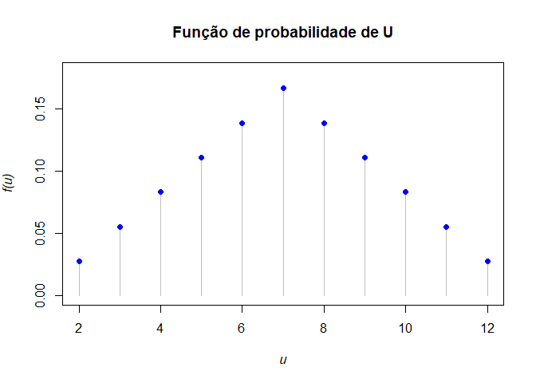

```r
plot(x=acontU$soma,y=acontU$prob,type='h',xlab=substitute(paste(italic('u'))),ylab=substitute(paste(italic('f(u)'))),main="Função de probabilidade de U",ylim=c(0,0.18),col="grey")
points(x=acontU$soma,y=acontU$prob,pch=16,col="blue")
```

Como output é desenhada o gráfico da função de probabilidade: $f(u)$.

## Exercício 3

Utiliza-se o comando *cumsum()* para o valor das probabilidades irem acumulando-se, ao aumentarmos os valores da 1ª coluna da tabela.

```r
Fu <- cumsum(acontU$prob)
Fu
```

```
##  [1] 0.02777778 0.08333333 0.16666667 0.27777778 0.41666667 0.58333333
##  [7] 0.72222222 0.83333333 0.91666667 0.97222222 1.00000000
```

É retornado um vetor com as distribuições para cada uma das somas, no lançamento dos dois dados.

## Exercício 4

A função de distribuição com ramos é escrita da seguinte forma:

$$F(u)= \left \{
\begin{array}{ll}
0 & u < 2 \\
0.0278 & 2 \le u < 3 \\
0.0833 & 3 \le u < 4 \\
0.1667 & 4 \le u < 5 \\
0.2778 & 5 \le u < 6 \\
0.4167 & 6 \le u < 7 \\
0.5833 & 7 \le u < 8 \\
0.7222 & 8 \le u < 9 \\
0.8333 & 9 \le u < 10 \\
0.9167 & 10 \le u < 11 \\
0.9722 & 11 \le u < 12 \\
1 & u \ge 12 \\
\end{array}
\right.$$

Com a função por ramos construída torna-se mais fácil de identificar a probabilidade de tirar uma soma de números inferiores ou superiores a um certo valor ou, ainda, de tirar uma certa soma de valores.

*Por exemplo: probabilidade da soma ser inferior a 9 é de 0.7222.*

## Exercício 5

Para desenhar a função de distribuição será utilizado o comando *plot.stefun* com alguns parâmetros no comando, com a finalidade de desenhar linhas horizontais acumulativas face à probabilidade dos acontecimentos, observados na função por ramos anterior (*exercício 4*).

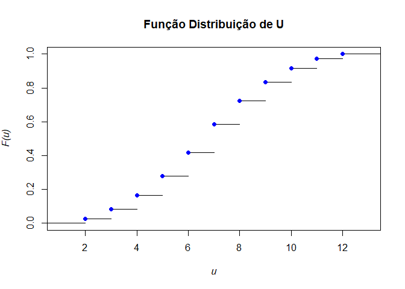

```r
plot.stepfun(stepfun(acontU$soma,c(0,Fu),right=FALSE),verticals=FALSE,pch = 16,
main="Função Distribuição de U", xlab=substitute(paste(italic("u"))),ylab=substitute(paste(italic("F(u)"))),col.points="blue")
```

Como output, foi mostrado o gráfico relativo à função de distribuição de U: $F(U)$.

## Exercício 6

Pretende-se calcular a probabilidade da variável aleatória;

$P[7\le U \le 10]$

### a) com recurso à função probabilidade

É necessário retirar da tabela do acontecimento *U*, os valores de $f(u)∈ [7,10]$, para, em seguida, serem somados e assim obter-se a probabilidade pretendida.

```r
sum(acontU[acontU$soma>=7&acontU$soma<=10,]$prob)
```

```
## [1] 0.5
```

### b) com recurso à função distribuição

Para calcular com recurso à função distribuição é necessário utilizar a variável **$Fu$**, *do exercício 3* e retirar do vetor os valores em que a soma é 7 e em que a soma é 10, ou seja, em que *u=10* e *u=7*. E, ainda, somar a $f(u)=7$, pois também se quer incluir o 7 à soma da probabilidade. Assim tem-se;

$P[7\le U \le 10]=F(10)-F(7)+f(7)$

```r
Fu[which(acontU$soma==10)]-Fu[which(acontU$soma==7)] + acontU$prob[acontU$soma==7]
```

```
## [1] 0.5
```

Como output, nas duas alíneas, foi retirado o mesmo valor de probabilidade, $P[7\le U \le 10]$= **0.5**.

## Exercício 7

Pretende-se calcular a probabilidade de;

$P[7 < U \le 10]$

### a) através da função probabilidade

Serão retirados da tabela do acontecimento *U* os valores de $f(u)∈ ]7,10]$ e serão somados.

```r
sum(acontU$prob[acontU$soma>7&acontU$soma<=10])
```

```
## [1] 0.3333333
```

### b) através da função distribuição

Utiliza-se a função distribuição quando o valor de $f(u)$ está entre *u=10* e *u=7*.

```r
Fu[which(acontU$soma==10)]-Fu[which(acontU$soma==7)]
```

```
## [1] 0.3333333
```

Ou seja, pelas duas funções concluímos que $P[7 < U \le 10]$= **0.333**.

## Exercício 8

Pretende-se calcular a probabilidade de;

$P[7 < U < 10]$

### a) através da função probabilidade

Serão retirados da tabela do acontecimento *U* os valores de $f(u)∈ ]7,10[$ e serão somados.

```r
sum(acontU$prob[acontU$soma>7&acontU$soma<10])
```

```
## [1] 0.25
```

### b) através da função distribuição

Para utilizar-se a função de distribuição é necessário descobrir uma expressão equivalente a $P[7 < U < 10]$. Neste caso, em concreto, pode-se utilizar a relação $P[7 < U \le 9]$, pois $<10 =\le9$, é semelhante dizer-se, nesta variável discreta.

```r
Fu[which(acontU$soma==9)]-Fu[which(acontU$soma==7)]
```

```
## [1] 0.25
```

Ou seja, pelas duas funções concluímos que $P[7 < U < 10]$= **0.25**.

## Exercício 9

Para calcular a variância e o desvio padrão, pelas fórmulas gerais, irá realizar-se o valor esperado do quadrado dos desvios face à média, onde se retira o valor da variância. Após isso, faz-se a raiz quadrada desse valor, de modo a obter o desvio padrão.

$\operatorname {var}(U)=\operatorname {E}[(U-\mu )^{2}]$, variância de $U$

${\displaystyle \sigma ={\sqrt {var(U) }}={\sqrt {\sigma^2 }}}$, desvio padrão de $U$

```r
miuU <- sum(acontU$soma*acontU$prob)
miuU
```

```
## [1] 7
```

```r
varU <- sum(acontU$soma^2*acontU$prob)-miuU^2
varU
```

```
## [1] 5.833333
```

```r
dpU <- sqrt(varU)
dpU
```

```
## [1] 2.415229
```

Logo, a média = **7**, ${\sigma^2}_{U}=$ **5.833** (variância) e ${\sigma}_{U}=$ **2.415** (desvio padrão).